# Práctica de Aprendizaje No Supervisado

## Clustering Jerárquico

En este métodos de clustering se construye una estructura en base a una medida de similitud entre los individuos, formando matrices de distancia; se subdividen en 2 tipos:

- **Aglomerativos:** Inicialmente se forman clusters individuales, el algoritmo va sucesivamente agrupando en clusters más grandes. El procedimiento finaliza cuando solo haya un cluster.
- **Divisivos:** Se parte de un único cluster al que pertenecen todos los elementos. El procedimiento finaliza cuando hayan tanto clusters como individuos.

Para nuestro datos utilizaremos el tipo *aglomerativo*, vale destacar que en este exiten 3 métricas para decidir el agrupamiento

- ward: une a los cluster de acuerdo a la minima distancia *euclídiana*
- Average (promedio): busca minimizar la distancia promedio entre los cluster.
- Complete: para cada par de cluster, se busca minimizar la máxima distancia entre ellos.

```python
from scipy.cluster.hierarchy import dendrogram, linkage
from scipy.cluster.hierarchy import cophenet
from scipy.spatial.distance import pdist
```

#### Método Ward

```python
Z = linkage(ndf, 'ward')
c, coph_dists = cophenet(Z, pdist(ndf))
c
#(pdist(ndf, 'euclidean')).shape
#from scipy.spatial.distance import squareform
#res = pdist(ndf, 'euclidean')
#squareform(res) < 0.7
```

```
0.55713803281564467
```

Los cluster se suelen representar a tráves de Dendogramas:

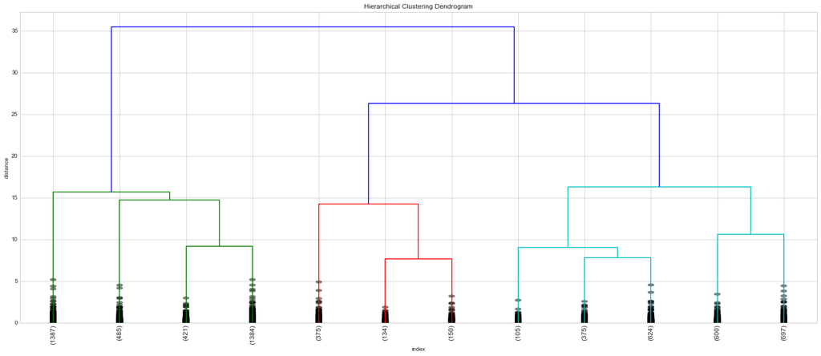

```python
plt.figure(figsize=(25, 10))
plt.title('Hierarchical Clustering Dendrogram')
plt.xlabel('index')
plt.ylabel('distance')
dendrogram(
    Z,
    truncate_mode='lastp',  # show only the last p merged clusters
    p=12,  # show only the last p merged clusters
    leaf_rotation=90.,
    leaf_font_size=12.,
    show_contracted=True,
)
plt.show()
```

#### Con average:

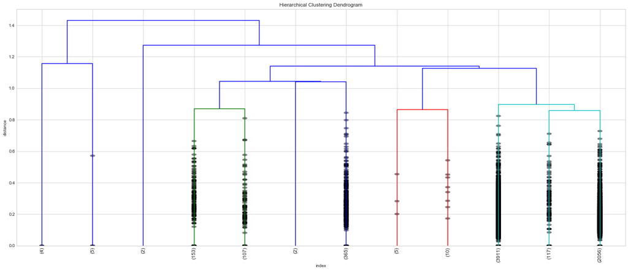

```python
Z = linkage(ndf, 'average')
plt.figure(figsize=(25, 10))
plt.title('Hierarchical Clustering Dendrogram')
plt.xlabel('index')
plt.ylabel('distance')
dendrogram(
    Z,
    truncate_mode='lastp',  # show only the last p merged clusters
    p=12,  # show only the last p merged clusters
    leaf_rotation=90.,
    leaf_font_size=12.,
    show_contracted=True,
)
plt.show()
```

#### Con Complete:

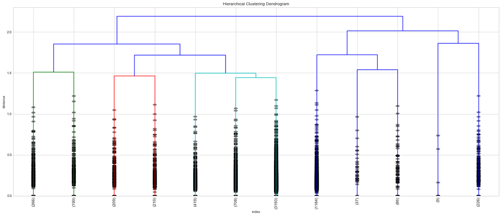

```python
Z = linkage(ndf, 'complete')
plt.figure(figsize=(25, 10))
plt.title('Hierarchical Clustering Dendrogram')
plt.xlabel('index')
plt.ylabel('distance')
dendrogram(
     Z,
    truncate_mode='lastp',  # show only the last p merged clusters
    p=12,  # show only the last p merged clusters
    leaf_rotation=90.,
    leaf_font_size=12.,
    show_contracted=True,
)
plt.show()
```

Con los distinto metodos (*ward, complete y average*) es dificil extraer conclusiones, ¿tal vez 3 cluster?

Revisaremos que caracteristicas tienen cada uno de los **3 clusters** arrojado con según *ward*

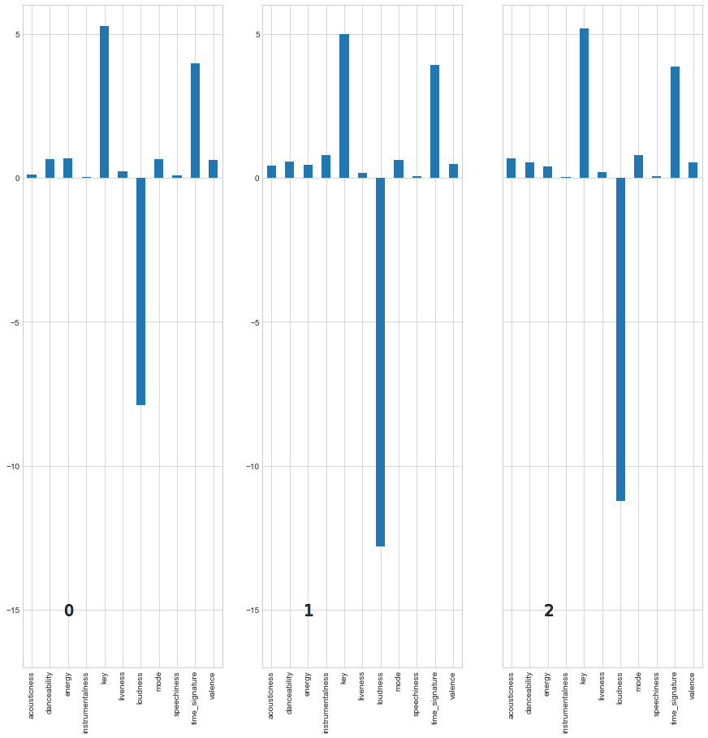

```
Silhouette Coefficient: 0.430
```

```python
from scipy.cluster.hierarchy import fcluster
k=3
Z = linkage(ndf, 'ward')
labels = fcluster(Z, k, criterion='maxclust')
plot_center_cluster(songs, labels, 1,3,list_x=[1,2,3],list_y= [1,2,0],  fy= 15, fx = 15)
print("Silhouette Coefficient: %0.3f"
      % metrics.silhouette_score(ndf, labels, metric='sqeuclidean'))
```

```python
songs.loc[songs.clusters ==3,:].head(500)
```

|  | year | rank | song | singer | danceability | energy | key | loudness | mode | speechiness | ... | valence | tempo | type | id | uri | track_href | analysis_url | duration_ms | time_signature | clusters |
| --- | --- | --- | --- | --- | --- | --- | --- | --- | --- | --- | --- | --- | --- | --- | --- | --- | --- | --- | --- | --- | --- |
| 0 | 1940 | 1 | White Christmas | Bing Crosby | 0.676 | 0.2930 | 11 | -9.720 | 1 | 0.0366 | ... | 0.3320 | 102.241 | audio_features | 0ggEJo3cuFtpj6Yzh3U3au | spotify:track:0ggEJo3cuFtpj6Yzh3U3au | https://api.spotify.com/v1/tracks/0ggEJo3cuFtp... | https://api.spotify.com/v1/audio-analysis/0ggE... | 193387 | 4 | 3 |
| 1 | 1940 | 2 | The Christmas Song | Nat “King” Cole | 0.242 | 0.2430 | 7 | -16.246 | 1 | 0.0337 | ... | 0.1520 | 133.185 | audio_features | 6dFyDoMXhljPvqv0PdWKf7 | spotify:track:6dFyDoMXhljPvqv0PdWKf7 | https://api.spotify.com/v1/tracks/6dFyDoMXhljP... | https://api.spotify.com/v1/audio-analysis/6dFy... | 219213 | 4 | 3 |
| 2 | 1940 | 3 | God Bless The Child | Billie Holiday | 0.254 | 0.1540 | 0 | -13.296 | 1 | 0.0396 | ... | 0.2430 | 174.018 | audio_features | 3XvnBthQEEN3TS0ruO2DWO | spotify:track:3XvnBthQEEN3TS0ruO2DWO | https://api.spotify.com/v1/tracks/3XvnBthQEEN3... | https://api.spotify.com/v1/audio-analysis/3Xvn... | 181600 | 3 | 3 |
| 3 | 1940 | 4 | Take The “A” Train | Duke Ellington | 0.467 | 0.5240 | 9 | -13.217 | 0 | 0.0547 | ... | 0.6500 | 93.518 | audio_features | 7wIXVc9m8wRuP9YVALlQN7 | spotify:track:7wIXVc9m8wRuP9YVALlQN7 | https://api.spotify.com/v1/tracks/7wIXVc9m8wRu... | https://api.spotify.com/v1/audio-analysis/7wIX... | 159133 | 4 | 3 |
| 5 | 1940 | 6 | Swinging On A Star | Bing Crosby | 0.964 | 0.2750 | 10 | -13.516 | 1 | 0.0497 | ... | 0.8220 | 115.978 | audio_features | 1Gelr53RPFzaIwGSPNbqlT | spotify:track:1Gelr53RPFzaIwGSPNbqlT | https://api.spotify.com/v1/tracks/1Gelr53RPFza... | https://api.spotify.com/v1/audio-analysis/1Gel... | 176480 | 4 | 3 |
| 6 | 1940 | 7 | You Always Hurt The One You Love | Mills Brothers | 0.388 | 0.2510 | 6 | -15.040 | 1 | 0.1310 | ... | 0.2460 | 132.099 | audio_features | 0GPp6WSrMSs0y3AmFLK2iJ | spotify:track:0GPp6WSrMSs0y3AmFLK2iJ | https://api.spotify.com/v1/tracks/0GPp6WSrMSs0... | https://api.spotify.com/v1/audio-analysis/0GPp... | 182533 | 4 | 3 |
| 7 | 1940 | 8 | Boogie Woogie Bugle Boy | Andrews Sisters | 0.650 | 0.4170 | 10 | -10.349 | 1 | 0.0463 | ... | 0.9240 | 78.201 | audio_features | 3FbVtdHTgBWZVtEJvzDlvP | spotify:track:3FbVtdHTgBWZVtEJvzDlvP | https://api.spotify.com/v1/tracks/3FbVtdHTgBWZ... | https://api.spotify.com/v1/audio-analysis/3FbV... | 136707 | 4 | 3 |
| 8 | 1940 | 9 | Chattanooga Choo Choo | Glenn Miller (Tex Beneke &amp;theModernaires) | 0.425 | 0.5700 | 1 | -11.026 | 1 | 0.0506 | ... | 0.7550 | 170.426 | audio_features | 3hvIhgOb5MenEDHQQRfzo6 | spotify:track:3hvIhgOb5MenEDHQQRfzo6 | https://api.spotify.com/v1/tracks/3hvIhgOb5Men... | https://api.spotify.com/v1/audio-analysis/3hvI... | 204453 | 4 | 3 |
| 9 | 1940 | 10 | Paper Doll | Mills Brothers | 0.539 | 0.1660 | 0 | -18.107 | 1 | 0.0611 | ... | 0.3900 | 142.354 | audio_features | 5pgds9R3Q1d2CLeo4yRkVb | spotify:track:5pgds9R3Q1d2CLeo4yRkVb | https://api.spotify.com/v1/tracks/5pgds9R3Q1d2... | https://api.spotify.com/v1/audio-analysis/5pgd... | 182000 | 4 | 3 |
| 10 | 1940 | 11 | Rudolph, The Red-Nosed Reindeer | Gene Autry | 0.718 | 0.4250 | 2 | -13.310 | 1 | 0.0847 | ... | 0.9520 | 108.296 | audio_features | 66adQmwm3TP5B7pYcSge4v | spotify:track:66adQmwm3TP5B7pYcSge4v | https://api.spotify.com/v1/tracks/66adQmwm3TP5... | https://api.spotify.com/v1/audio-analysis/66ad... | 84400 | 4 | 3 |
| 11 | 1940 | 12 | Sentimental Journey | Les Brown (Doris Day) | 0.607 | 0.2810 | 5 | -13.401 | 0 | 0.0396 | ... | 0.5390 | 126.301 | audio_features | 0Hw6RO14yXRlWn096oUMZi | spotify:track:0Hw6RO14yXRlWn096oUMZi | https://api.spotify.com/v1/tracks/0Hw6RO14yXRl... | https://api.spotify.com/v1/audio-analysis/0Hw6... | 146440 | 4 | 3 |
| 12 | 1940 | 13 | I’ll Be Seeing You | Bing Crosby Tommy Dorsey (Frank Sinatra) | 0.458 | 0.2470 | 10 | -14.657 | 0 | 0.0429 | ... | 0.3230 | 135.521 | audio_features | 1QFuvPCvN5z4sj7Dvx5a8x | spotify:track:1QFuvPCvN5z4sj7Dvx5a8x | https://api.spotify.com/v1/tracks/1QFuvPCvN5z4... | https://api.spotify.com/v1/audio-analysis/1QFu... | 329520 | 4 | 3 |
| 14 | 1940 | 15 | Riders In The Sky (A Cowboy Legend) | Vaughn Monroe Peggy Lee | 0.476 | 0.1960 | 3 | -14.113 | 1 | 0.0324 | ... | 0.2030 | 113.853 | audio_features | 7oAUubVkyEXAf9b59mOJUh | spotify:track:7oAUubVkyEXAf9b59mOJUh | https://api.spotify.com/v1/tracks/7oAUubVkyEXA... | https://api.spotify.com/v1/audio-analysis/7oAU... | 191093 | 3 | 3 |
| 15 | 1940 | 16 | Auld Lang Syne | Guy Lombardo | 0.365 | 0.3950 | 7 | -7.884 | 1 | 0.0283 | ... | 0.1970 | 77.927 | audio_features | 2xLbxiLKxZmsJhyJNBpf7C | spotify:track:2xLbxiLKxZmsJhyJNBpf7C | https://api.spotify.com/v1/tracks/2xLbxiLKxZms... | https://api.spotify.com/v1/audio-analysis/2xLb... | 225373 | 4 | 3 |
| 17 | 1940 | 18 | Don’t Fence Me In | Bing Crosby &amp; the Andrews Sisters Roy Ro... | 0.726 | 0.2880 | 8 | -10.189 | 1 | 0.0571 | ... | 0.5660 | 96.219 | audio_features | 1BinHpdg6S3m4x21BXGv7F | spotify:track:1BinHpdg6S3m4x21BXGv7F | https://api.spotify.com/v1/tracks/1BinHpdg6S3m... | https://api.spotify.com/v1/audio-analysis/1Bin... | 181760 | 4 | 3 |
| 18 | 1940 | 19 | Jingle, Jangle, Jingle | Kay Kyser Gene Autry | 0.551 | 0.3030 | 9 | -9.821 | 1 | 0.0390 | ... | 0.6520 | 92.750 | audio_features | 5zwO4Tw8V8v29L3h7jeW0Q | spotify:track:5zwO4Tw8V8v29L3h7jeW0Q | https://api.spotify.com/v1/tracks/5zwO4Tw8V8v2... | https://api.spotify.com/v1/audio-analysis/5zwO... | 226880 | 4 | 3 |
| 20 | 1940 | 21 | Nature Boy | Nat “King” Cole Frank Sinatra Sarah Vaughan | 0.376 | 0.0808 | 3 | -18.475 | 1 | 0.0339 | ... | 0.0712 | 63.545 | audio_features | 3Mq43FFjNnqd6Arv4qBIq6 | spotify:track:3Mq43FFjNnqd6Arv4qBIq6 | https://api.spotify.com/v1/tracks/3Mq43FFjNnqd... | https://api.spotify.com/v1/audio-analysis/3Mq4... | 377747 | 4 | 3 |
| 22 | 1940 | 23 | Green Eyes | Jimmy Dorsey (Bob Eberly &amp; Helen O’Connell) | 0.423 | 0.3080 | 0 | -11.442 | 0 | 0.0431 | ... | 0.6670 | 154.893 | audio_features | 3usP8cPRugRWAjMqh97N7H | spotify:track:3usP8cPRugRWAjMqh97N7H | https://api.spotify.com/v1/tracks/3usP8cPRugRW... | https://api.spotify.com/v1/audio-analysis/3usP... | 164040 | 3 | 3 |
| 23 | 1940 | 24 | Frenesi | Artie Shaw | 0.638 | 0.6130 | 11 | -4.632 | 1 | 0.0388 | ... | 0.5540 | 122.994 | audio_features | 5uiPrVjqzHYZKXCLHVR3jU | spotify:track:5uiPrVjqzHYZKXCLHVR3jU | https://api.spotify.com/v1/tracks/5uiPrVjqzHYZ... | https://api.spotify.com/v1/audio-analysis/5uiP... | 201649 | 4 | 3 |
| 24 | 1940 | 25 | Till The End Of Time | Perry Como Les Brown Dick Haymes | 0.508 | 0.3690 | 1 | -8.213 | 1 | 0.0306 | ... | 0.1620 | 172.020 | audio_features | 4FaTrcMMVc7YKVJkuWmrtE | spotify:track:4FaTrcMMVc7YKVJkuWmrtE | https://api.spotify.com/v1/tracks/4FaTrcMMVc7Y... | https://api.spotify.com/v1/audio-analysis/4FaT... | 226008 | 4 | 3 |
| 25 | 1940 | 26 | Lover Man (Oh Where Can You Be) | Billie Holiday Sarah Vaughan | 0.402 | 0.0859 | 5 | -16.275 | 0 | 0.0375 | ... | 0.2740 | 74.028 | audio_features | 3h0AeMbMN3imfMKU9Cxm8D | spotify:track:3h0AeMbMN3imfMKU9Cxm8D | https://api.spotify.com/v1/tracks/3h0AeMbMN3im... | https://api.spotify.com/v1/audio-analysis/3h0A... | 203453 | 3 | 3 |
| 27 | 1940 | 28 | Stormy Weather | Lena Horne | 0.180 | 0.0878 | 5 | -19.114 | 1 | 0.0454 | ... | 0.1150 | 166.147 | audio_features | 74zCqI1errV9tRO6nrMfmH | spotify:track:74zCqI1errV9tRO6nrMfmH | https://api.spotify.com/v1/tracks/74zCqI1errV9... | https://api.spotify.com/v1/audio-analysis/74zC... | 199924 | 3 | 3 |
| 28 | 1940 | 29 | This Land Is Your Land | Woody Guthrie | 0.511 | 0.7020 | 7 | -4.895 | 1 | 0.0371 | ... | 0.8520 | 116.999 | audio_features | 6iLHSfrDwcdhVeyV3WXDBn | spotify:track:6iLHSfrDwcdhVeyV3WXDBn | https://api.spotify.com/v1/tracks/6iLHSfrDwcdh... | https://api.spotify.com/v1/audio-analysis/6iLH... | 295613 | 4 | 3 |
| 29 | 1940 | 30 | You Are My Sunshine | Jimmie Davis | 0.769 | 0.0615 | 5 | -23.581 | 1 | 0.0490 | ... | 0.6080 | 98.017 | audio_features | 4aRdSvmPiAPGbQfsbMM0ny | spotify:track:4aRdSvmPiAPGbQfsbMM0ny | https://api.spotify.com/v1/tracks/4aRdSvmPiAPG... | https://api.spotify.com/v1/audio-analysis/4aRd... | 171293 | 4 | 3 |
| 30 | 1940 | 31 | That Lucky Old Sun | Frankie Laine Vaughn Monroe | 0.312 | 0.1570 | 10 | -14.993 | 1 | 0.0323 | ... | 0.3910 | 176.988 | audio_features | 0dPS1kignN2T3fTQN7WHqh | spotify:track:0dPS1kignN2T3fTQN7WHqh | https://api.spotify.com/v1/tracks/0dPS1kignN2T... | https://api.spotify.com/v1/audio-analysis/0dPS... | 217000 | 3 | 3 |
| 31 | 1940 | 32 | (I Love You) For Sentimental Reasons | Nat “King” Cole Eddy Howard Dinah Shore | 0.469 | 0.1830 | 6 | -9.204 | 0 | 0.0329 | ... | 0.3180 | 73.194 | audio_features | 53gV4yfBcRS4QXwF633c9d | spotify:track:53gV4yfBcRS4QXwF633c9d | https://api.spotify.com/v1/tracks/53gV4yfBcRS4... | https://api.spotify.com/v1/audio-analysis/53gV... | 284253 | 4 | 3 |
| 32 | 1940 | 33 | (I’ve Got A Gal In) Kalamazoo | Glenn Miller (Marion Hutton &amp; the Moderna... | 0.736 | 0.3650 | 6 | -9.547 | 1 | 0.0395 | ... | 0.7540 | 133.097 | audio_features | 0MlvRRuIOQE5x2rjTFxyF4 | spotify:track:0MlvRRuIOQE5x2rjTFxyF4 | https://api.spotify.com/v1/tracks/0MlvRRuIOQE5... | https://api.spotify.com/v1/audio-analysis/0Mlv... | 195027 | 4 | 3 |
| 35 | 1940 | 36 | Maria Elena | Jimmy Dorsey Wayne King | 0.638 | 0.2140 | 9 | -12.609 | 1 | 0.0763 | ... | 0.7730 | 137.277 | audio_features | 0aOaM8vjsegOeHPwMwEdo4 | spotify:track:0aOaM8vjsegOeHPwMwEdo4 | https://api.spotify.com/v1/tracks/0aOaM8vjsegO... | https://api.spotify.com/v1/audio-analysis/0aOa... | 145880 | 3 | 3 |
| 36 | 1940 | 37 | A String Of Pearls | Glenn Miller | 0.638 | 0.3040 | 2 | -9.150 | 0 | 0.0603 | ... | 0.4560 | 127.815 | audio_features | 4ylJmlihbVrONWxaUhs6YG | spotify:track:4ylJmlihbVrONWxaUhs6YG | https://api.spotify.com/v1/tracks/4ylJmlihbVrO... | https://api.spotify.com/v1/audio-analysis/4ylJ... | 218000 | 4 | 3 |
| 38 | 1940 | 39 | Manana (Is Soon Enough For Me) | Peggy Lee | 0.487 | 0.5040 | 4 | -9.010 | 0 | 0.1030 | ... | 0.6530 | 70.165 | audio_features | 69Dw4xDQLAKthcvmNk88vJ | spotify:track:69Dw4xDQLAKthcvmNk88vJ | https://api.spotify.com/v1/tracks/69Dw4xDQLAKt... | https://api.spotify.com/v1/audio-analysis/69Dw... | 147773 | 4 | 3 |
| ... | ... | ... | ... | ... | ... | ... | ... | ... | ... | ... | ... | ... | ... | ... | ... | ... | ... | ... | ... | ... | ... |
| 714 | 1953 | 21 | Perry Como | Say You’re Mine Again | 0.456 | 0.2030 | 0 | -13.325 | 1 | 0.0315 | ... | 0.2950 | 92.585 | audio_features | 7AKcL327XzMtmfY4FYDfmx | spotify:track:7AKcL327XzMtmfY4FYDfmx | https://api.spotify.com/v1/tracks/7AKcL327XzMt... | https://api.spotify.com/v1/audio-analysis/7AKc... | 206107 | 4 | 3 |
| 716 | 1953 | 23 | Frankie Laine and Jimmy Boyd | Tell Me A Story | 0.835 | 0.3660 | 1 | -8.215 | 1 | 0.0532 | ... | 0.9610 | 122.095 | audio_features | 1THl7yjezM9SW8x2taVS5w | spotify:track:1THl7yjezM9SW8x2taVS5w | https://api.spotify.com/v1/tracks/1THl7yjezM9S... | https://api.spotify.com/v1/audio-analysis/1THl... | 130933 | 4 | 3 |
| 719 | 1953 | 26 | Joni James | Your Cheating Heart | 0.339 | 0.0455 | 8 | -18.407 | 1 | 0.0302 | ... | 0.3610 | 84.500 | audio_features | 7LDYBeUEX78Qu5kdRSgB2G | spotify:track:7LDYBeUEX78Qu5kdRSgB2G | https://api.spotify.com/v1/tracks/7LDYBeUEX78Q... | https://api.spotify.com/v1/audio-analysis/7LDY... | 170800 | 4 | 3 |
| 721 | 1953 | 28 | Eddie Fisher | With These Hands | 0.242 | 0.3410 | 1 | -5.320 | 1 | 0.0286 | ... | 0.1340 | 81.772 | audio_features | 47SAIBYtLSowmI0n2DkLka | spotify:track:47SAIBYtLSowmI0n2DkLka | https://api.spotify.com/v1/tracks/47SAIBYtLSow... | https://api.spotify.com/v1/audio-analysis/47SA... | 168800 | 4 | 3 |
| 722 | 1953 | 29 | Eartha Kitt | C’est Si Bon | 0.525 | 0.3950 | 5 | -11.025 | 0 | 0.0768 | ... | 0.4930 | 76.215 | audio_features | 07UjFjAVwQ5b3jWCWS4Etd | spotify:track:07UjFjAVwQ5b3jWCWS4Etd | https://api.spotify.com/v1/tracks/07UjFjAVwQ5b... | https://api.spotify.com/v1/audio-analysis/07Uj... | 177000 | 4 | 3 |
| 723 | 1953 | 30 | Joni James | Have You Heard? | 0.310 | 0.0298 | 8 | -23.313 | 1 | 0.0359 | ... | 0.1600 | 126.128 | audio_features | 5XGOV27XOce5EOF6ar9szs | spotify:track:5XGOV27XOce5EOF6ar9szs | https://api.spotify.com/v1/tracks/5XGOV27XOce5... | https://api.spotify.com/v1/audio-analysis/5XGO... | 181213 | 4 | 3 |
| 724 | 1954 | 1 | Kitty Kallen | Little Things Mean A Lot | 0.238 | 0.1240 | 8 | -14.607 | 1 | 0.0349 | ... | 0.1930 | 63.519 | audio_features | 30F5DTdI9dYwW69OEe0L56 | spotify:track:30F5DTdI9dYwW69OEe0L56 | https://api.spotify.com/v1/tracks/30F5DTdI9dYw... | https://api.spotify.com/v1/audio-analysis/30F5... | 213960 | 3 | 3 |
| 725 | 1954 | 2 | Perry Como | Wanted | 0.456 | 0.2030 | 0 | -13.325 | 1 | 0.0315 | ... | 0.2950 | 92.585 | audio_features | 7AKcL327XzMtmfY4FYDfmx | spotify:track:7AKcL327XzMtmfY4FYDfmx | https://api.spotify.com/v1/tracks/7AKcL327XzMt... | https://api.spotify.com/v1/audio-analysis/7AKc... | 206107 | 4 | 3 |
| 726 | 1954 | 3 | Rosemary Clooney | Hey There | 0.456 | 0.2030 | 0 | -13.325 | 1 | 0.0315 | ... | 0.2950 | 92.585 | audio_features | 7AKcL327XzMtmfY4FYDfmx | spotify:track:7AKcL327XzMtmfY4FYDfmx | https://api.spotify.com/v1/tracks/7AKcL327XzMt... | https://api.spotify.com/v1/audio-analysis/7AKc... | 206107 | 4 | 3 |
| 727 | 1954 | 4 | Crew Cuts | Sh-Boom | 0.693 | 0.3630 | 2 | -7.367 | 0 | 0.0665 | ... | 0.5160 | 129.134 | audio_features | 7I774iZM4QkJK6gFPEEmS0 | spotify:track:7I774iZM4QkJK6gFPEEmS0 | https://api.spotify.com/v1/tracks/7I774iZM4QkJ... | https://api.spotify.com/v1/audio-analysis/7I77... | 168333 | 4 | 3 |
| 728 | 1954 | 5 | Jo Stafford | Make Love To Me | 0.339 | 0.1980 | 7 | -11.284 | 1 | 0.0367 | ... | 0.3090 | 100.442 | audio_features | 37Cw4QCCIaXznCB7rJFhnh | spotify:track:37Cw4QCCIaXznCB7rJFhnh | https://api.spotify.com/v1/tracks/37Cw4QCCIaXz... | https://api.spotify.com/v1/audio-analysis/37Cw... | 149219 | 4 | 3 |
| 729 | 1954 | 6 | Eddie Fisher | Oh! My Pa-pa | 0.396 | 0.2160 | 10 | -7.362 | 1 | 0.0286 | ... | 0.4130 | 96.882 | audio_features | 2LglXhKn4uFuwkyAI8tGxg | spotify:track:2LglXhKn4uFuwkyAI8tGxg | https://api.spotify.com/v1/tracks/2LglXhKn4uFu... | https://api.spotify.com/v1/audio-analysis/2Lgl... | 185467 | 4 | 3 |
| 731 | 1954 | 8 | Four Aces | Three Coins In The Fountain | 0.382 | 0.0962 | 3 | -21.807 | 1 | 0.0316 | ... | 0.5140 | 78.030 | audio_features | 3myhs1DFwJnd5TA4RZl1Hc | spotify:track:3myhs1DFwJnd5TA4RZl1Hc | https://api.spotify.com/v1/tracks/3myhs1DFwJnd... | https://api.spotify.com/v1/audio-analysis/3myh... | 180733 | 4 | 3 |
| 732 | 1954 | 9 | Doris Day | Secret Love | 0.280 | 0.1510 | 11 | -14.317 | 1 | 0.0355 | ... | 0.1760 | 76.222 | audio_features | 2dX2phLETbjqZA0D78ms4T | spotify:track:2dX2phLETbjqZA0D78ms4T | https://api.spotify.com/v1/tracks/2dX2phLETbjq... | https://api.spotify.com/v1/audio-analysis/2dX2... | 218253 | 4 | 3 |
| 733 | 1954 | 10 | Archie Bleyer | Hernando’s Hideaway | 0.690 | 0.1300 | 5 | -13.250 | 1 | 0.0576 | ... | 0.8640 | 147.086 | audio_features | 1yBoHaYonxq7LmhvZhUBoD | spotify:track:1yBoHaYonxq7LmhvZhUBoD | https://api.spotify.com/v1/tracks/1yBoHaYonxq7... | https://api.spotify.com/v1/audio-analysis/1yBo... | 157067 | 4 | 3 |
| 734 | 1954 | 11 | Frank Sinatra | Young At Heart | 0.349 | 0.2650 | 8 | -11.545 | 1 | 0.0307 | ... | 0.4280 | 85.279 | audio_features | 1ApoDRVGxx3Zd6Eo5BvrNR | spotify:track:1ApoDRVGxx3Zd6Eo5BvrNR | https://api.spotify.com/v1/tracks/1ApoDRVGxx3Z... | https://api.spotify.com/v1/audio-analysis/1Apo... | 169166 | 4 | 3 |
| 735 | 1954 | 12 | Rosemary Clooney | This Ole House | 0.777 | 0.3870 | 0 | -15.990 | 1 | 0.0670 | ... | 0.9700 | 117.433 | audio_features | 10q6ZbFxjqAN1GOdd3dPal | spotify:track:10q6ZbFxjqAN1GOdd3dPal | https://api.spotify.com/v1/tracks/10q6ZbFxjqAN... | https://api.spotify.com/v1/audio-analysis/10q6... | 140387 | 4 | 3 |
| 736 | 1954 | 13 | Eddie Fisher | I Need You Now | 0.777 | 0.3870 | 0 | -15.990 | 1 | 0.0670 | ... | 0.9700 | 117.433 | audio_features | 10q6ZbFxjqAN1GOdd3dPal | spotify:track:10q6ZbFxjqAN1GOdd3dPal | https://api.spotify.com/v1/tracks/10q6ZbFxjqAN... | https://api.spotify.com/v1/audio-analysis/10q6... | 140387 | 4 | 3 |
| 737 | 1954 | 14 | Patti Page | Cross Over The Bridge | 0.573 | 0.6150 | 4 | -9.976 | 1 | 0.1120 | ... | 0.8650 | 134.177 | audio_features | 4OAEEIyG2E9t0lHUXnmTan | spotify:track:4OAEEIyG2E9t0lHUXnmTan | https://api.spotify.com/v1/tracks/4OAEEIyG2E9t... | https://api.spotify.com/v1/audio-analysis/4OAE... | 156160 | 3 | 3 |
| 738 | 1954 | 15 | Gaylords | The Little Shoemaker | 0.893 | 0.2760 | 7 | -13.305 | 1 | 0.0738 | ... | 0.9650 | 125.424 | audio_features | 7vf8gkfY5VbonMv26EPqif | spotify:track:7vf8gkfY5VbonMv26EPqif | https://api.spotify.com/v1/tracks/7vf8gkfY5Vbo... | https://api.spotify.com/v1/audio-analysis/7vf8... | 137133 | 4 | 3 |
| 739 | 1954 | 16 | Dean Martin | That’s Amore | 0.481 | 0.2190 | 10 | -10.070 | 1 | 0.0275 | ... | 0.5280 | 79.381 | audio_features | 6GYqOflskcZxPj8rkTZkOy | spotify:track:6GYqOflskcZxPj8rkTZkOy | https://api.spotify.com/v1/tracks/6GYqOflskcZx... | https://api.spotify.com/v1/audio-analysis/6GYq... | 185467 | 4 | 3 |
| 740 | 1954 | 17 | Frank Weir | The Happy Wanderer | 0.574 | 0.1220 | 5 | -18.035 | 1 | 0.0464 | ... | 0.5640 | 121.403 | audio_features | 2dG38n6Z3hvUaJhLHiBMpf | spotify:track:2dG38n6Z3hvUaJhLHiBMpf | https://api.spotify.com/v1/tracks/2dG38n6Z3hvU... | https://api.spotify.com/v1/audio-analysis/2dG3... | 161573 | 4 | 3 |
| 741 | 1954 | 18 | Nat King Cole | Answer Me My Love | 0.187 | 0.2430 | 2 | -13.505 | 1 | 0.0318 | ... | 0.2750 | 86.620 | audio_features | 2QU6TB1v0iHoAiwRsBTqKu | spotify:track:2QU6TB1v0iHoAiwRsBTqKu | https://api.spotify.com/v1/tracks/2QU6TB1v0iHo... | https://api.spotify.com/v1/audio-analysis/2QU6... | 176293 | 1 | 3 |
| 742 | 1954 | 19 | Tony Bennett | Stranger In Paradise | 0.203 | 0.2130 | 11 | -14.343 | 1 | 0.0312 | ... | 0.1350 | 84.009 | audio_features | 4q34EABWsdvbC8vUuzDSq5 | spotify:track:4q34EABWsdvbC8vUuzDSq5 | https://api.spotify.com/v1/tracks/4q34EABWsdvb... | https://api.spotify.com/v1/audio-analysis/4q34... | 183200 | 4 | 3 |
| 743 | 1954 | 20 | Doris Day | If I Give My Heart To You | 0.509 | 0.0495 | 9 | -17.218 | 1 | 0.0483 | ... | 0.3500 | 81.284 | audio_features | 0r3WlJRaUXf8cqkhzjuPPJ | spotify:track:0r3WlJRaUXf8cqkhzjuPPJ | https://api.spotify.com/v1/tracks/0r3WlJRaUXf8... | https://api.spotify.com/v1/audio-analysis/0r3W... | 169240 | 4 | 3 |
| 744 | 1954 | 21 | Kay Starr | If You Love Me (Really Love Me) | 0.344 | 0.3450 | 2 | -11.341 | 1 | 0.0344 | ... | 0.4280 | 109.531 | audio_features | 3EDOhWyUVEuiKSlV0h7cJK | spotify:track:3EDOhWyUVEuiKSlV0h7cJK | https://api.spotify.com/v1/tracks/3EDOhWyUVEui... | https://api.spotify.com/v1/audio-analysis/3EDO... | 168333 | 3 | 3 |
| 745 | 1954 | 22 | Ralph Marterie | Skokiaan | 0.329 | 0.4380 | 10 | -8.322 | 1 | 0.0395 | ... | 0.8450 | 179.832 | audio_features | 2N6zHhrMcelwvFUslH4s6l | spotify:track:2N6zHhrMcelwvFUslH4s6l | https://api.spotify.com/v1/tracks/2N6zHhrMcelw... | https://api.spotify.com/v1/audio-analysis/2N6z... | 168747 | 4 | 3 |
| 747 | 1954 | 24 | Patti Page | Changing Partners | 0.393 | 0.4290 | 5 | -8.761 | 1 | 0.0537 | ... | 0.4970 | 70.774 | audio_features | 4jJFnoYTVBtAIdOhtXdpdc | spotify:track:4jJFnoYTVBtAIdOhtXdpdc | https://api.spotify.com/v1/tracks/4jJFnoYTVBtA... | https://api.spotify.com/v1/audio-analysis/4jJF... | 103893 | 4 | 3 |
| 748 | 1954 | 25 | Perry Como | Papa Loves Mambo | 0.644 | 0.6220 | 0 | -5.573 | 1 | 0.0593 | ... | 0.9250 | 82.112 | audio_features | 7kAPDls7pfsXdb9xTUXNiT | spotify:track:7kAPDls7pfsXdb9xTUXNiT | https://api.spotify.com/v1/tracks/7kAPDls7pfsX... | https://api.spotify.com/v1/audio-analysis/7kAP... | 160333 | 4 | 3 |
| 750 | 1954 | 27 | Tony Bennett | Rags To Riches | 0.648 | 0.4080 | 0 | -18.291 | 1 | 0.5400 | ... | 0.9670 | 124.000 | audio_features | 1DNLLd54YLHWV9apCEJPJm | spotify:track:1DNLLd54YLHWV9apCEJPJm | https://api.spotify.com/v1/tracks/1DNLLd54YLHW... | https://api.spotify.com/v1/audio-analysis/1DNL... | 77027 | 4 | 3 |